# Análisis estadístico del Analfabetismo en el Perú

[figure not shown]

[figure not shown]

[figure not shown]

[figure not shown]

[figure not shown]

[figure not shown]

[figure not shown]

[figure not shown]

[figure not shown]

[figure not shown]

[figure not shown]

[figure not shown]

[1 more figures not shown]

# Introducción

### Información sobre el tema

**INTRODUCCIÓN AL TEMA**: El analfabetismo es un problema social el cual afecta a miles de ciudadanos alrededor del mundo, es por ello que analizar e investigar sobre las causas asociadas al analfabetismo es relevante para poder reducir el problema. En primer lugar, el analfabetismo definido por Juan Jiménez involucra dos características: La incapacidad de ciertos individuos de hacer frente a las exigencias de la vida diaria y no haber cumplido los tres años de escolaridad. Otros autores mencionan que es no tener habilidad de escribir o leer. El analfabetismo es, pues, un fenómeno histórica y culturalmente construido. Implica también relaciones de poder: decir quién sabe leer y escribir y quién no, cuáles saberes son valiosos o inválidos; decidir, según esos saberes, quién puede participar y quién no, son formas de control y autoridad (Kalman, 2004; Street, 2004). Ser una persona analfabeta implica varias dificultades en la vida y pérdida de oportunidades. En el Perú, la tasa de analfabetismo se ha reducido en estos años hasta llegar a 5.9% (Gobierno del Perú), sin embargo esto no implica que haya desaparecido, por ende encontramos importante analizar las causas de por qué este problema continúa.

**VARIABLE DEPENDIENTE**: Porcentaje del Analfabetismo en el Perú por provincia: Este valor proporcionado por la INEI nos apoyará en ver cuáles son las variables independientes relacionadas al analfabetismo y cuáles son los factores de por qué ciertas provincias tienen porcentajes más altos de analfabetismo que otros

**VARIABLES INDICADAS COMO PREDICTORAS**:

- PORCENTAJE DE ZONAS RURALES: Las zonas rurales han sido el factor más mencionado en los trabajos sobre el analfabetismo, debido a que en estas zonas hay menor accesibilidad a sistemas y apoyos educativos que en las zonas urbanas
- PORCENTAJE CON 1 NBI: Las necesidad básicas insatisfechas pueden causar que las personas no puedan acceder a la educación
- MAYOR PORCENTAJE DE MUJERES: A varias mujeres en el Perú se les niega el acceso a la alfabetización debido a creencias o problemas económicos
- PORCENTAJE DE PERSONAS SIN WIFI: El wifi y el internet se han vuelto una variable relevante para la educación y acceder a ella, por ello su falta puede causar mayores niveles de analfabetismo
- PORCENTAJE DE LENGUA: El español al ser el idioma más hablado en el Perú hace que los servicios educativos sean en español y se creen pocos en los demás idiomas que encontramos en el Perú, dejando a personas sin acceso a la educación y por ende, analfabetas.
- PORCENTAJE DE DISCAPACIDAD: Las discapacidades complican recibir una buena educación y pocas escuelas están capacitadas en enseñar a personas que tienen alguna discapacidad, por ende lo consideramos una de nuestras variables para ver si tiene relación un alto nivel de discapacidad a un alto nivel de analfabetismo

### Hipótesis

**PREGUNTA DE INVESTIGACIÓN**: ¿Cuáles son las variables que causan que el porcentaje de analfabetismo en las provincias incremente?

**HIPÓTESIS**: En las provincias del Perú, la tasa de analfabetismo está influenciada por varios factores socioeconómicos y culturales. En primer lugar, las provincias rurales tienen una tasa de analfabetismo más alta debido a la menor disponibilidad de recursos educativos, infraestructura y acceso a servicios básicos. Las mujeres, especialmente en zonas rurales, pueden enfrentarse a barreras adicionales como roles tradicionales de género, lo que puede llevar a una mayor tasa de analfabetismo entre ellas. La presencia de comunidades que hablan lenguas originarias, que no tienen una adecuada integración con el sistema educativo en español, podría resultar en dificultades para acceder a educación formal y, por lo tanto, aumentar la tasa de analfabetismo. Además, el índice de desigualdad (medido por el índice de Gini) podría estar relacionado con mayores disparidades en el acceso a educación, lo que también impactaría negativamente la tasa de alfabetización en zonas con alta desigualdad. Finalmente, la falta de acceso a tecnología y a internet (sin wifi) podría ser un factor determinante, ya que en la era digital el acceso a recursos educativos en línea y a información se ha vuelto crucial para el aprendizaje, y la ausencia de estos servicios podría limitar las oportunidades educativas y aumentar la tasa de analfabetismo.

# Análsisi bivariado

### Analfabetismo + Porcentaje de lenguas

En el análisis bivariado veremos nuestras variables a través de Spearman debido a que algunas provincias con mayor población pueden resultar como valores atípicos

```
$estimate
      rho
0.5422629

$p.value
[1] 4.529907e-16
```

- Resultado: Encontramos que estas dos variables están correlacionadas, por ende nos servirá en nuestro análisis multivariado. Esto nos indica que a mayor porcentaje de diversidad de lenguas que tenga una provincia, mayor porcentaje de analfabetismo hay en esta parte. Esto nos lleva a pensar que los colegios no se pueden adaptar a otros idiomas y por ende varias personas se quedan sin acceso a la educación.

### Analfabetismo + Porcentaje de zonas rurales

```
$estimate
      rho
0.6017675

$p.value
[1] 2.682908e-20
```

- Resultado: Nuestra siguiente variable presenta una correlacionalidad con analfabetismo, lo cual significa que va a ser relevante para nuestra investigación

### Analfabetismo + Porcentaje de mujeres

```
$estimate
       rho
-0.3682012

$p.value
[1] 1.485062e-07
```

- Resultado: Acá presentamos un estimado en negativo lo cual nos indica que a mayor porcentaje de mujeres es menor el analfabetismo. A pesar de contradecir nuestra hipótesis inicial, esta puede ser explicada por los datos del INEI cuando se trata de educación (Redatam), El porcentaje de hombres y mujeres que entran a los grados como primaria o inicial son muy similares, sin embargo cuando vemos la educación superior, las mujeres tienen un mayor porcentaje que los hombres. Esto significa que en el Perú las mujeres están presentando un gran avance. Sin embargo esto no descarta que varios estudios han mostrado las complicaciones de las mujeres en recibir educación. Igualmente la variable será usada para nuestro análisis

### Analfabetismo + Porcentaje de discapacidad

```
$estimate
        rho
0.006981933

$p.value
[1] 0.9234301
```

- Resultado: En este caso la variable no presenta significancia para el modelo, por ende no entrará en nuestro trabajo.

### Analfabetismo + Porcentaje de 1NBI

```
$estimate
       rho
0.04024869

$p.value
[1] 0.5793837
```

- Resultado: Vemos que una necesidad bàsica insatisfecha no encuentra correlación con el analfabetismo, pero tal vez más de una necesidad insatisfecha podría encontrar relación

### Analfabetismo + Porcentaje sin wifi

```
$estimate
       rho
-0.5572576

$p.value
[1] 4.673564e-17
```

- Resultado: Vemos que SIN WIFI se presenta relevante. Acá se presenta que a menor porcentaje de personas sin wifi, es mayor el analfabetismo. Por ende es una variable que nos va a apoyar en nuestra investigación

# Análisis multivariado

### Modelo 1

- Hipótesis 1: El porcentaje de analfabetismo por provincia incrementa o disminuye dependiendo el porcentaje de lengua y el porcentaje de zonas rurales
- Explicación: Estas dos variables salieron significativas, además son las zonas rurales las que cuentan con mayores tasas de personas que hablan distintas lenguas. Por ende encontramos relevantes juntarlas para ver el modelo

```
Call:
lm(formula = modelo6, data = result)

Residuals:
    Min      1Q  Median      3Q     Max
-9.3849 -2.7738 -0.3294  2.7369 14.6520

Coefficients:
                          Estimate Std. Error t value Pr(>|t|)
(Intercept)                4.85375    0.66590   7.289 8.28e-12 ***
result$`Rural porcentaje`  8.46706    1.19285   7.098 2.48e-11 ***
result$PORCENTAJELENGUA    0.09918    0.01151   8.620 2.65e-15 ***
---
Signif. codes:  0 '***' 0.001 '**' 0.01 '*' 0.05 '.' 0.1 ' ' 1

Residual standard error: 4.367 on 189 degrees of freedom
Multiple R-squared:  0.5443,    Adjusted R-squared:  0.5394
F-statistic: 112.9 on 2 and 189 DF,  p-value: < 2.2e-16
```

### Modelo 2

- Hipótesis 2: El porcentaje de analfabetismo por provincia incrementa o disminuye dependiendo el porcentaje de lengua, el porcentaje de zonas rurales y el porcentaje de mujeres en las provincias

```
Call:
lm(formula = modelo7, data = result)

Residuals:
     Min       1Q   Median       3Q      Max
-10.2939  -2.4862  -0.0186   2.5155  12.4897

Coefficients:
                            Estimate Std. Error t value Pr(>|t|)
(Intercept)                 58.59636    7.49342   7.820 3.68e-13 ***
result$`Rural porcentaje`    9.81046    1.07541   9.123  < 2e-16 ***
result$PORCENTAJELENGUA      0.08057    0.01054   7.646 1.04e-12 ***
result$`Porcentaje Mujer` -107.43326   14.93289  -7.194 1.45e-11 ***
---
Signif. codes:  0 '***' 0.001 '**' 0.01 '*' 0.05 '.' 0.1 ' ' 1

Residual standard error: 3.877 on 188 degrees of freedom
Multiple R-squared:  0.6427,    Adjusted R-squared:  0.637
F-statistic: 112.7 on 3 and 188 DF,  p-value: < 2.2e-16
```

### Modelo 3

- Hipótesis 3: El porcentaje de analfabetismo por provincia incrementa o disminuye dependiendo el porcentaje de lengua, el porcentaje de zonas rurales, el porcentaje de mujeres y el porcentaje de personas sin wifi en las provincias

```
Call:
lm(formula = modelo8, data = result)

Residuals:
     Min       1Q   Median       3Q      Max
-10.5135  -2.3205  -0.4411   2.2396  12.1644

Coefficients:
                            Estimate Std. Error t value Pr(>|t|)
(Intercept)                 68.39017    7.80134   8.766 1.12e-15 ***
result$`Rural porcentaje`    4.89776    1.75230   2.795 0.005731 **
result$PORCENTAJELENGUA      0.07681    0.01029   7.463 3.10e-12 ***
result$`Porcentaje Mujer` -118.12138   14.82654  -7.967 1.55e-13 ***
result$`SIN WIFI`          -17.98222    5.14934  -3.492 0.000598 ***
---
Signif. codes:  0 '***' 0.001 '**' 0.01 '*' 0.05 '.' 0.1 ' ' 1

Residual standard error: 3.767 on 187 degrees of freedom
Multiple R-squared:  0.6645,    Adjusted R-squared:  0.6574
F-statistic: 92.61 on 4 and 187 DF,  p-value: < 2.2e-16
```

### Comparación de los 3 modelos

Resultados de todos los modelos

apropiacion (I)

apropiacion (II)

apropiacion (III)

(Intercept)

4.854***

58.596***

68.390***

(0.666)

(7.493)

(7.801)

result$Rural porcentaje

8.467***

9.810***

4.898**

(1.193)

(1.075)

(1.752)

result$PORCENTAJELENGUA

0.099***

0.081***

0.077***

(0.012)

(0.011)

(0.010)

result$Porcentaje Mujer

-107.433***

-118.121***

(14.933)

(14.827)

result$SIN WIFI

-17.982***

(5.149)

Num.Obs.

192

192

192

R2

0.544

0.643

0.665

R2 Adj.

0.539

0.637

0.657

AIC

1115.9

1071.2

1061.1

BIC

1128.9

1087.5

1080.6

Log.Lik.

-553.949

-530.602

-524.537

F

112.860

112.700

92.607

RMSE

4.33

3.84

3.72

- p < 0.1, * p < 0.05, ** p < 0.01, *** p < 0.001

### Gráfico

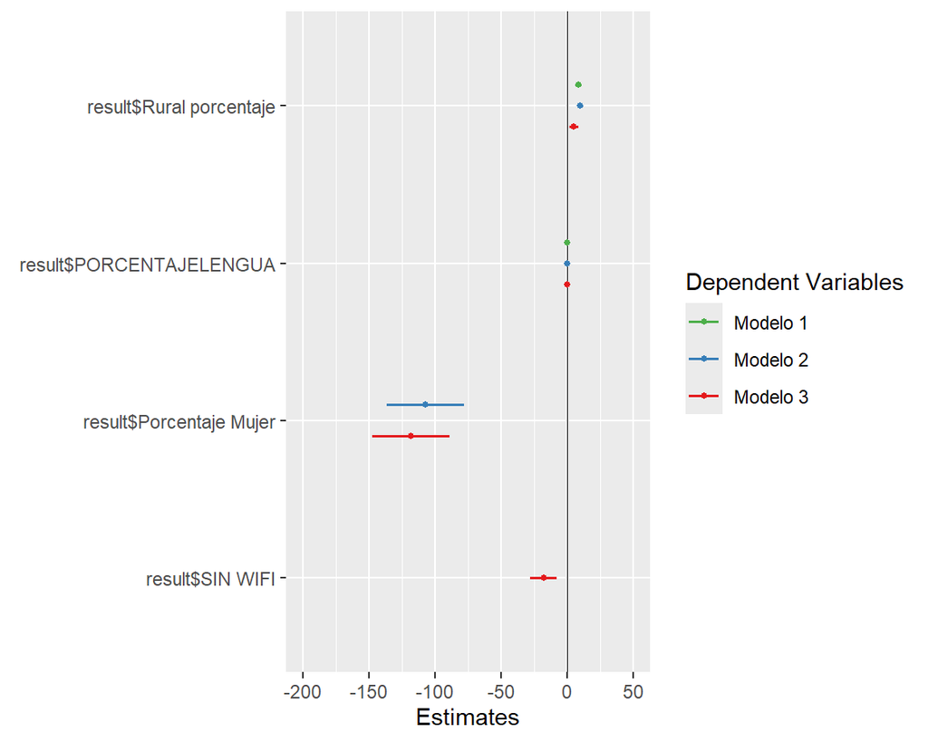

### Annova

Tabla ANOVA para comparar modelos

| Res.Df | RSS | Df | Sum of Sq | F | Pr(>F) |
| --- | --- | --- | --- | --- | --- |
| 189 | 3604.430 | NA | NA | NA | NA |
| 188 | 2826.303 | 1 | 778.1270 | 54.84164 | 0.0000000 |
| 187 | 2653.271 | 1 | 173.0312 | 12.19507 | 0.0005979 |

- Acá observamos que el tercer modelo el cual presentaba la hipótesis de que el analfabetismo resulta tener correlación con el porcentaje de lengua, zonas rurales, porcentaje de mujeres y porcentaje de personas sin wifi termina siendo nuestro mejor modelo explicativo.

# Modelo de regresión

### Linealidad

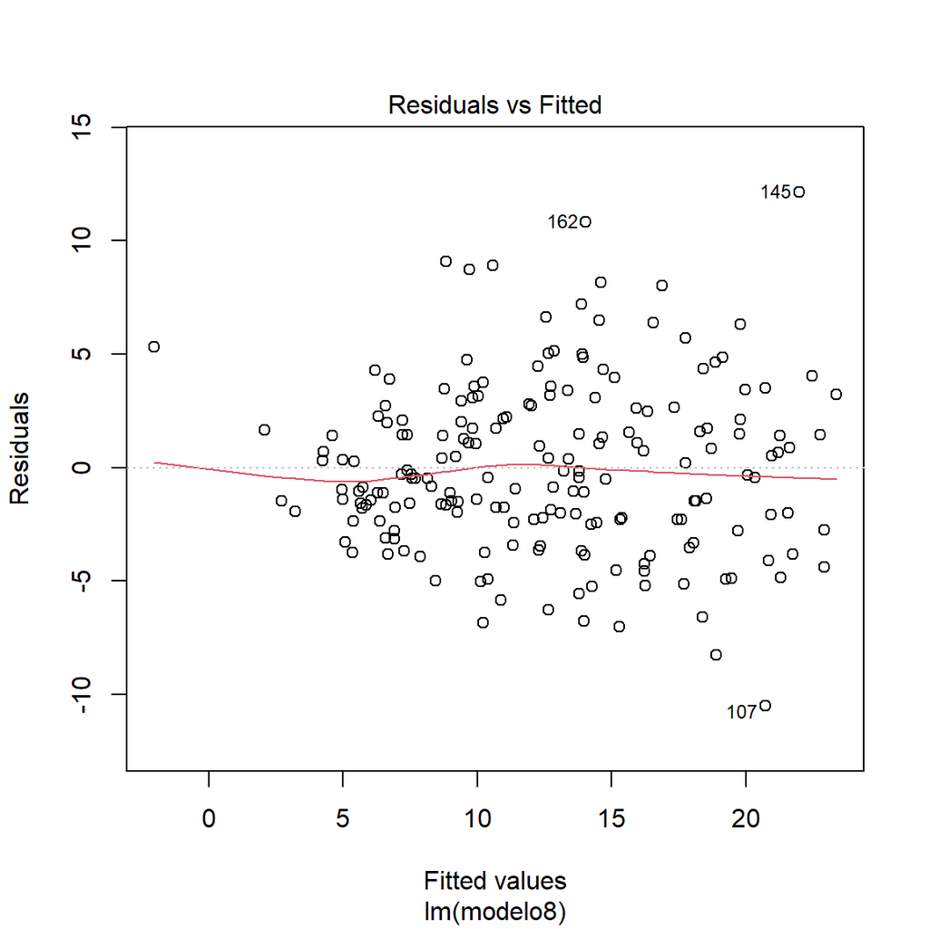

Resultado: Vemos una linealidad, sin embargo se observan valores atípicos. Aún así podemos observar una linealidad

### Homocedasticidad - Gráfico

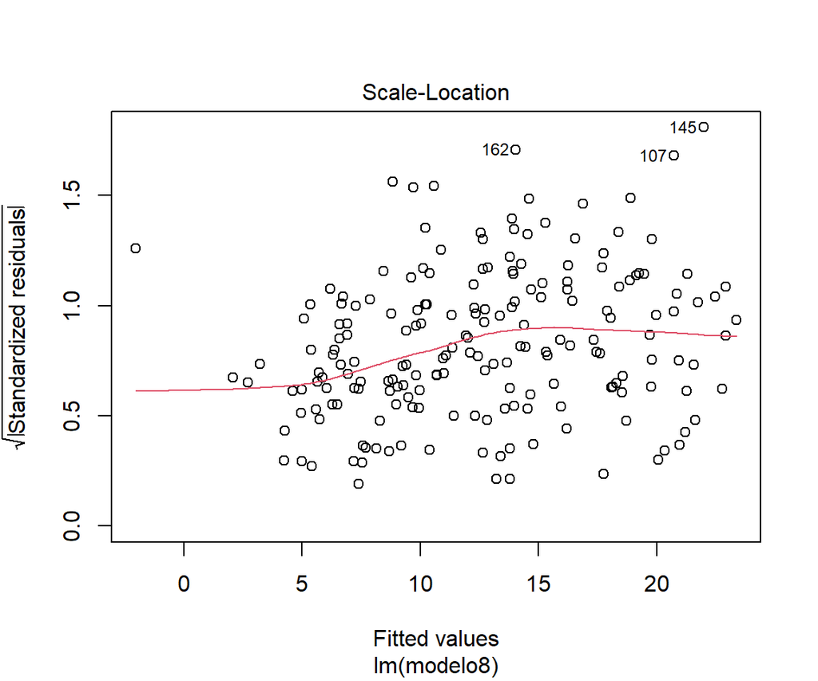

### Homocedasticidad - Tabla

studentized Breusch-Pagan test

|  | BP | df | p.value |
| --- | --- | --- | --- |
| BP | 11.83478 | 4 | 0.0186232 |

- Acá podemos observar que el test de Breusch - Pagan nos sugiere que el modelo presenta heterocedasticidad significativa.

### Normalidad de Residuos

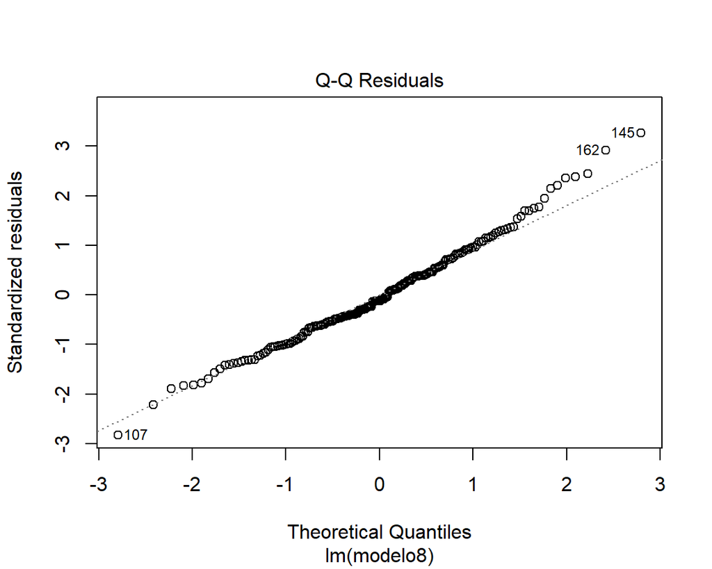

### Normalidad de residuos - Shapiro

Shapiro-Wilk normality test

|  | SW | p.value |
| --- | --- | --- |
| W | 0.9888998 | 0.1408228 |

- El test Shapiro nos muestra que los datos no presentan una desviación significativa de la normalidad.

### Multicolinealidad

Evaluando Multicolinealidad usando VIF (Variance Inflation Factors)

[output not shown]

- Según VIF, no hay un problema significativo de multicolinealidad ya que nadie supera el número 5

### Valores influyentes

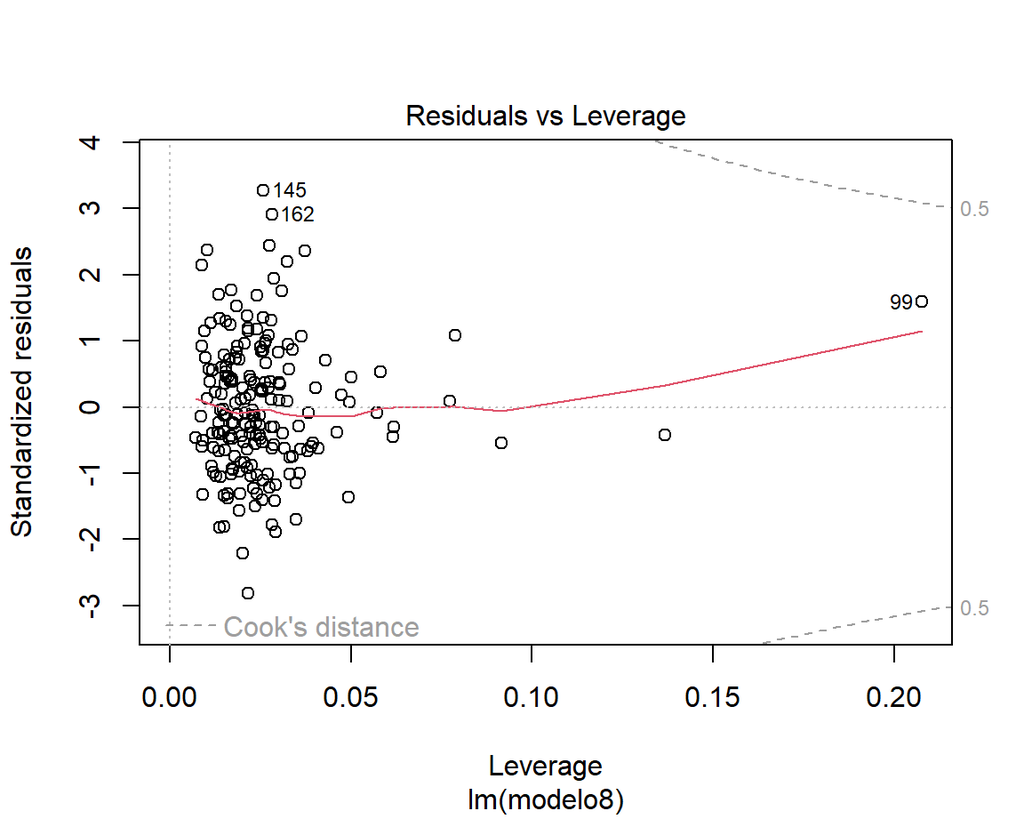

### Valores influyentes - tabla

Valores Influyentes críticos

[output not shown]

- El resultado es que no ha encontrado valores influyentes críticos que afecten el modelo.

# Análisis Factorial

### Tabla

```
                 Rural porcentaje SIN WIFI PORCENTAJELENGUA Porcentaje Mujer
Rural porcentaje             1.00    -0.84             0.45             0.07
SIN WIFI                    -0.84     1.00            -0.41            -0.16
PORCENTAJELENGUA             0.45    -0.41             1.00            -0.19
Porcentaje Mujer             0.07    -0.16            -0.19             1.00
```

### Grafico

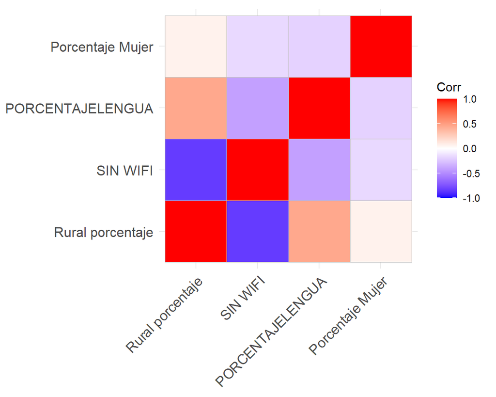

### Prueba - KMO

```
Kaiser-Meyer-Olkin factor adequacy
Call: psych::KMO(r = corMatrix)
Overall MSA =  0.59
MSA for each item =
Rural porcentaje         SIN WIFI PORCENTAJELENGUA Porcentaje Mujer
            0.57             0.56             0.77             0.36
```

- Con ello, tachamos el análisis factorial debido a que es inadecuado para el análisis factorial debido a tener un KMO de 0.59

# Análisis Conglomerado

### Boxplot

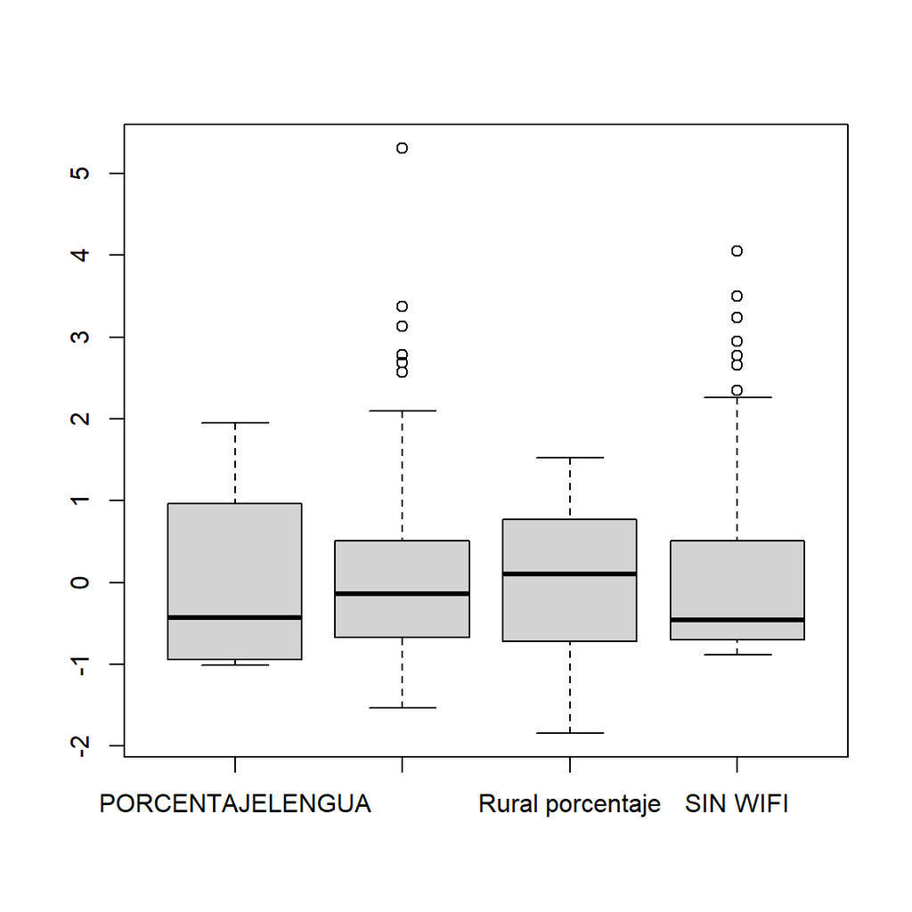

### PAM - Clusters

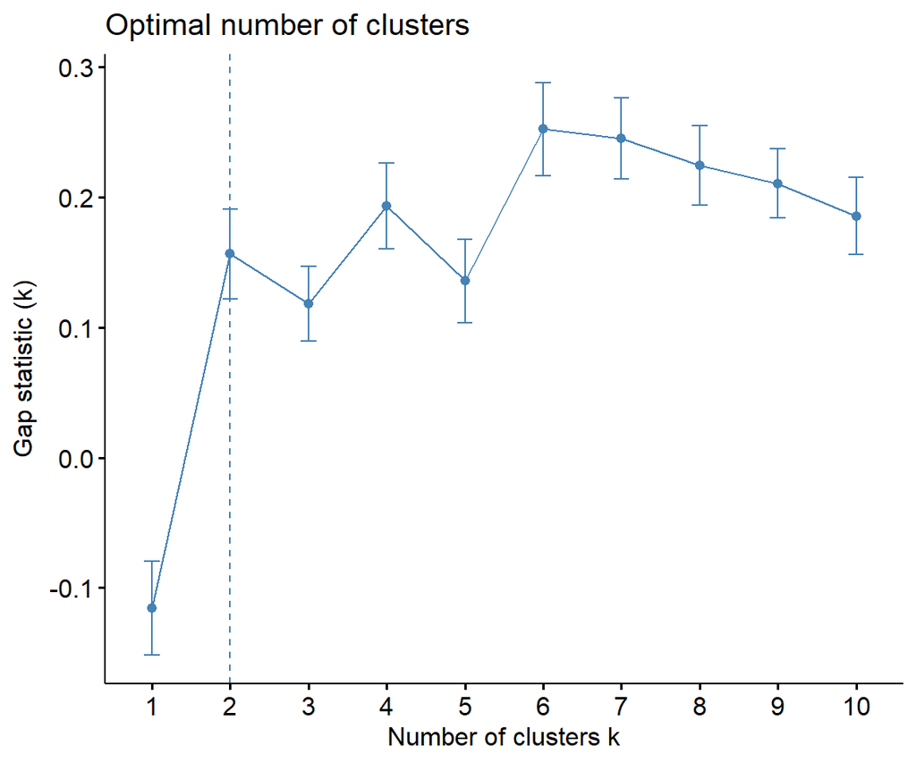

### PAM - Tabla

|  | PORCENTAJELENGUA | Porcentaje Mujer | Rural porcentaje | SIN WIFI | pam |
| --- | --- | --- | --- | --- | --- |
| ABANCAY | 50.3809265 | 0.4894227 | 0.3120514 | 0.1892909 | 1 |
| ACOBAMBA | 79.7476968 | 0.4775440 | 0.7451585 | 0.0268209 | 2 |
| ACOMAYO | 84.5117698 | 0.4888840 | 0.5790356 | 0.0090846 | 2 |
| AIJA | 41.5611146 | 0.5132996 | 1.0000000 | 0.0314214 | 2 |
| ALTO AMAZONAS | 11.3758403 | 0.5029130 | 0.3054914 | 0.0815264 | 1 |
| AMBO | 26.2244497 | 0.4906447 | 0.6614422 | 0.0550249 | 2 |
| ANDAHUAYLAS | 71.4108242 | 0.4832429 | 0.5377112 | 0.0922274 | 2 |
| ANGARAES | 72.7172963 | 0.4859878 | 0.7791162 | 0.0340360 | 2 |
| ANTA | 65.0055154 | 0.4930257 | 0.7130149 | 0.0568358 | 2 |
| ANTABAMBA | 76.5694076 | 0.5160920 | 1.0000000 | 0.0039216 | 2 |
| ANTONIO RAYMONDI | 76.5421245 | 0.4924542 | 1.0000000 | 0.0076394 | 2 |
| AREQUIPA | 17.1013339 | 0.4825256 | 0.0207377 | 0.3872590 | 1 |
| ASCOPE | 0.6062909 | 0.4924170 | 0.1115525 | 0.2659226 | 1 |
| ATALAYA | 50.6001135 | 0.5124888 | 0.5660224 | 0.0326458 | 2 |
| AYABACA | 0.9045411 | 0.5055706 | 0.8690408 | 0.0141560 | 2 |

### PAM - Siluetas

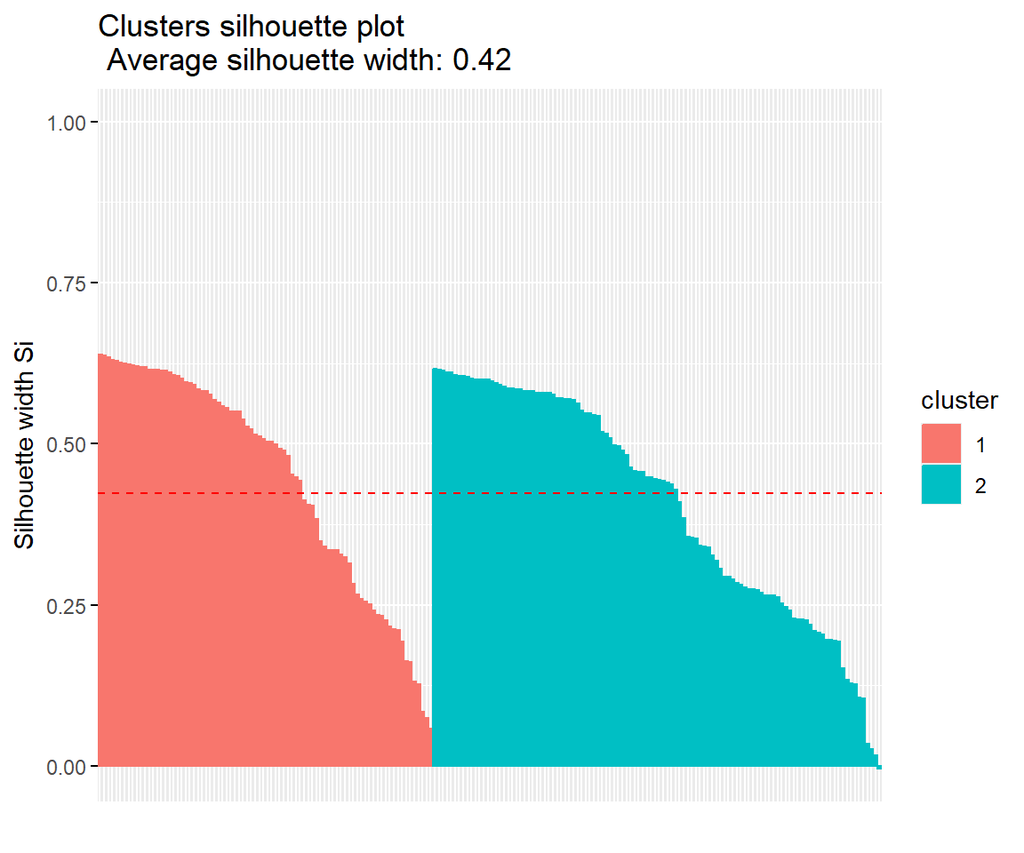

### PAM - Datos

```
[1] "BAGUA"
```

### AGNES - Clusters

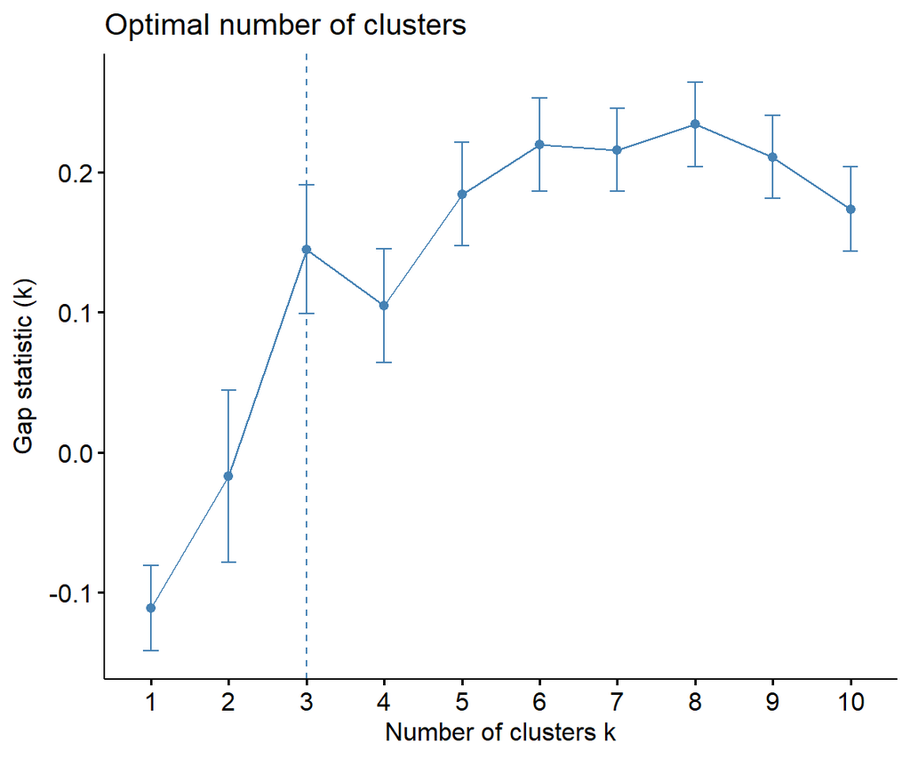

### AGNES - Tabla

|  | PORCENTAJELENGUA | Porcentaje Mujer | Rural porcentaje | SIN WIFI | pam | agnes |
| --- | --- | --- | --- | --- | --- | --- |
| ABANCAY | 50.3809265 | 0.4894227 | 0.3120514 | 0.1892909 | 1 | 1 |
| ACOBAMBA | 79.7476968 | 0.4775440 | 0.7451585 | 0.0268209 | 2 | 2 |
| ACOMAYO | 84.5117698 | 0.4888840 | 0.5790356 | 0.0090846 | 2 | 2 |
| AIJA | 41.5611146 | 0.5132996 | 1.0000000 | 0.0314214 | 2 | 3 |
| ALTO AMAZONAS | 11.3758403 | 0.5029130 | 0.3054914 | 0.0815264 | 1 | 3 |
| AMBO | 26.2244497 | 0.4906447 | 0.6614422 | 0.0550249 | 2 | 3 |
| ANDAHUAYLAS | 71.4108242 | 0.4832429 | 0.5377112 | 0.0922274 | 2 | 2 |
| ANGARAES | 72.7172963 | 0.4859878 | 0.7791162 | 0.0340360 | 2 | 2 |
| ANTA | 65.0055154 | 0.4930257 | 0.7130149 | 0.0568358 | 2 | 2 |
| ANTABAMBA | 76.5694076 | 0.5160920 | 1.0000000 | 0.0039216 | 2 | 2 |
| ANTONIO RAYMONDI | 76.5421245 | 0.4924542 | 1.0000000 | 0.0076394 | 2 | 2 |
| AREQUIPA | 17.1013339 | 0.4825256 | 0.0207377 | 0.3872590 | 1 | 1 |
| ASCOPE | 0.6062909 | 0.4924170 | 0.1115525 | 0.2659226 | 1 | 1 |
| ATALAYA | 50.6001135 | 0.5124888 | 0.5660224 | 0.0326458 | 2 | 2 |
| AYABACA | 0.9045411 | 0.5055706 | 0.8690408 | 0.0141560 | 2 | 3 |

### AGNES - Siluetas

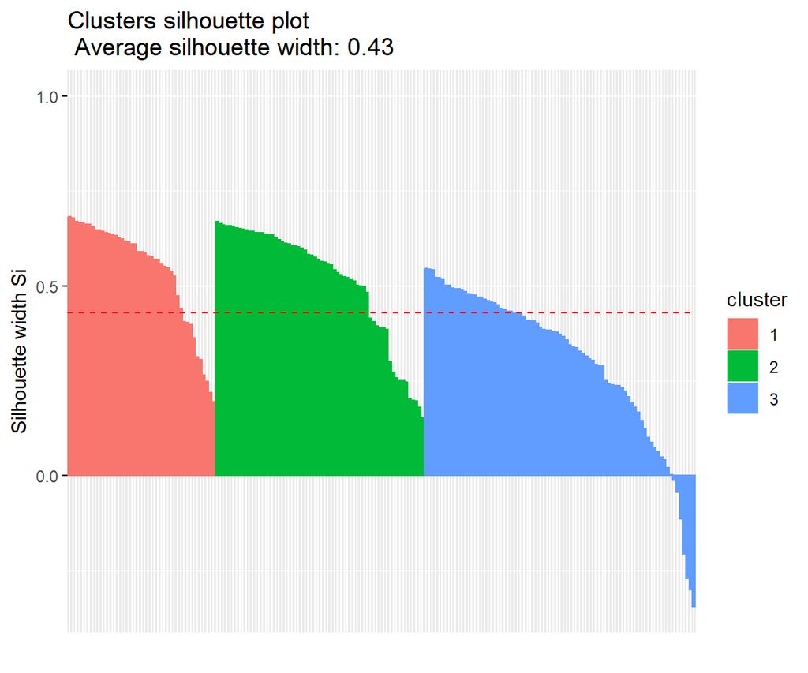

### AGNES - Datos

```
[1] "AIJA"      "CAJAMARCA" "FERREÑAFE" "HUANUCO"   "HUAYTARA"  "TARMA"
[7] "YAULI"
```

### DIANA - Clusters

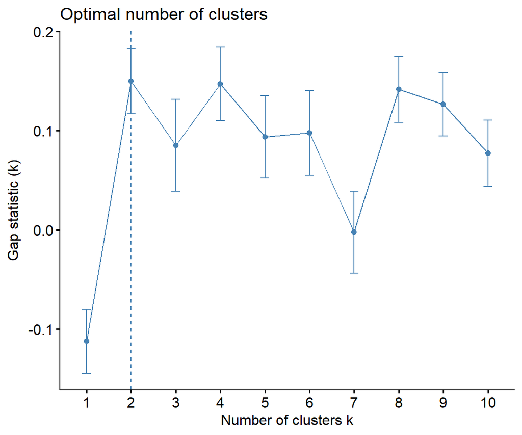